# Comparative Genomics Southern Flounder

# Family A Female Map

## Load data

Required inputfiles are `genfile`: `*.raw` generated using `convert.pl` to convert filtered `*.tsv`-output from haplotyper and `mapfile`: `*.map` text file with two columns (first column is putative linkage group, second column is markername). Need to create mapfile based on markers in genfile before analysis.

```r
# load data
FamA_F <- read.cross("mm", dir="data/LINKMAP/",
                     "FamA-F.raw", "FamA-F.map", estimate.map = FALSE)

# number of individuals/loci in data set
Sum_FamA_F.raw <- summary(FamA_F)
```

Raw data set contains 174 individuals and 1857 loci.

## Pre-mapping quality control

### Filter 1: Missing data

Missing genotypes (loci/individuals)

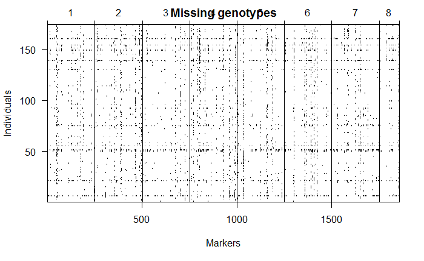

Omit loci with > 5% missing data and individuals with > 25% missing data.

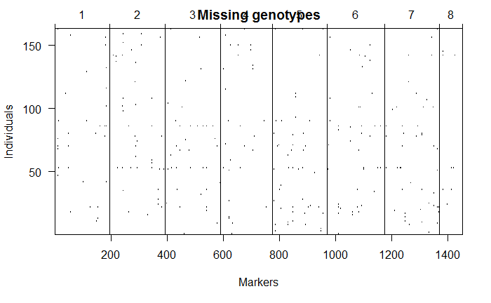

After filtering data set contains 163 individuals and 1453 loci.

### Filter 2: Omit duplicate individuals

Compare genotypes of pairs of individuals to identify pairs with unusually similar genotypes

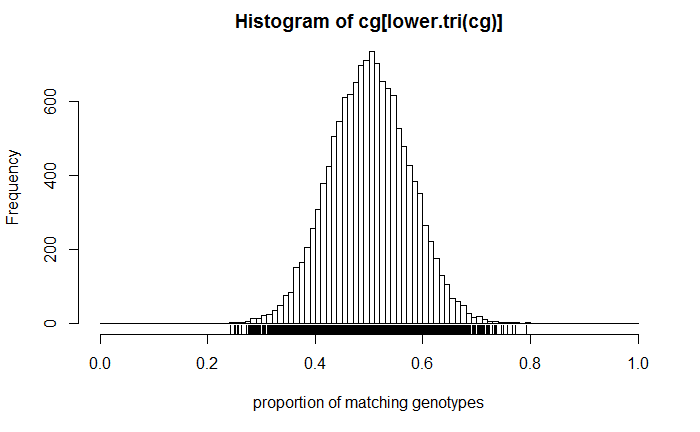

No matching individuals were identified.

```r
Sum_FamA_F.f2 <- summary(FamA_F.f2)
```

```
Some chromosomes > 1000 cM in length; there may be a problem with the genetic map.
  (Perhaps it is in basepairs?)
```

```r
Nind_F.f2 <- as.numeric(Sum_FamA_F.f2$n.ind)
Nloci_F.f2 <- sum(as.numeric(Sum_FamA_F.f2$n.mar))
```

Data set contains 163 individuals and 1453 loci.

### Filter 3: Omit duplicate markers

Identify matching markers. Drop duplicate markers but create table of corresponding marker to be mapped so the can be added post-mapping.

```r
# identify matching markers (matching genotypes/including missing data)
match.loci <- findDupMarkers(FamA_F.f2, exact.only = TRUE)

# keep table to add markers back in after mapping
match.loci_F <- ldply(match.loci, data.frame) %>%
  rename(LOCUS = `.id`, MATCHLOC = `X..i..`)

write.table(match.loci_F, file = "data/LINKMAP/MatchLociFamAF.txt",
            quote = FALSE, row.names = FALSE, sep = "\t")

# create list of matching loci
match.l <- as.character(match.loci_F$MATCHLOC)

# drop duplicate markers
FamA_F.f3 <- drop.markers(FamA_F.f2, match.l)

# number of individuals/loci in data set
Sum_FamA_F.f3 <- summary(FamA_F.f3)
Nind_F.f3 <- as.numeric(Sum_FamA_F.f3$n.ind)
Nloci_F.f3 <- sum(as.numeric(Sum_FamA_F.f3$n.mar))
```

After filtering 1031 loci are retained.

### Filter 4: Drop loci with distroted segregation patterns

Loci should have specific segregation patterns based on marker type.

```r
# calculate genotype frequencies and p-value (after Bonferroni correction)
geno.freq.l <- geno.table(FamA_F.f3)

# create list of markers with p-value <0.05
seg.dist.l <- geno.freq.l[geno.freq.l$P.value < 0.05/totmar(FamA_F.f3),]
drop.l.seg.dist <- rownames(geno.freq.l[geno.freq.l$P.value < 1e-10,])

# drop markers with significant (p<0.05) deviation from expected segregation patterns
FamA_F.f4 <- drop.markers(FamA_F.f3, drop.l.seg.dist)

# number of individuals/loci in data set
Sum_FamA_F.f4 <- summary(FamA_F.f4)
Nind_F.f4 <- as.numeric(Sum_FamA_F.f4$n.ind)
Nloci_F.f4 <- sum(as.numeric(Sum_FamA_F.f4$n.mar))
```

After filtering 1030 loci are retained.

### Filter 5: Genotype frequencies by individual

Determine genotype frequencies by individual and remove individuals as necessary.

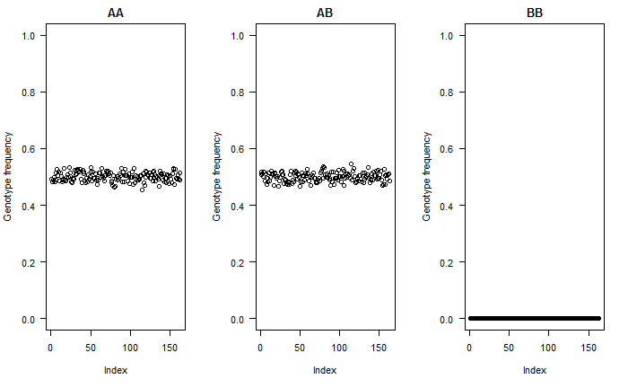

After filtering 163 individuals are retained.

## Determine correct linkage phase

Estimate recombination fraction (rf) & LOD score for each marker pair. Potentially switched markers are pairs of marker with strong association (LOD score) but rf >> 1/4.

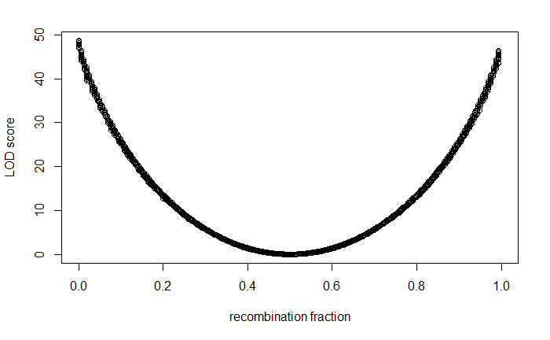

Form initial linkage groups and re-organize loci into initial LGs.

```r
# form initial linkage groups
init.lg <- formLinkageGroups(FamA_F.LP, max.rf = 0.35, min.lod = 6)
table(init.lg[,2])
```

```
 1  2  3  4  5  6  7  8  9 10 11 12 13 14 15 16 17 18 19 20 21 22 23 24 25 26 27 28 29 30 31
37 33 31 29 27 27 27 26 26 26 26 26 26 25 25 23 23 23 23 23 22 22 22 21 21 21 21 21 21 20 19
32 33 34 35 36 37 38 39 40 41 42 43 44 45 46 47 48 49 50
19 19 19 19 19 18 16 16 16 16 15 15 14 13 13 12  6  1  1
```

```r
# re-organize markers into inferred initial LGs
FamA_F.LP <- formLinkageGroups(FamA_F.LP, max.rf = 0.35, min.lod = 6, reorgMarkers=TRUE)
```

Plot rf vs LOD to identify chromosomes to switch alleles for.

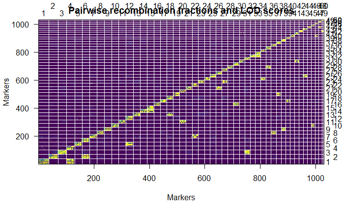

Switch alleles, re-estimate rf, form new linkage groups and re-organize markers.

```r
# form new linkage groups & re-organize markers
init.lg <- formLinkageGroups(FamA_F.LP, max.rf=0.35, min.lod=6)
table(init.lg[,2])
```

```
 1  2  3  4  5  6  7  8  9 10 11 12 13 14 15 16 17 18 19 20 21 22 23 24 25
66 60 53 50 50 49 49 49 45 44 43 43 42 41 40 40 39 39 38 36 36 29 26 22  1
```

```r
FamA_F.LP <- formLinkageGroups(FamA_F.LP, max.rf=0.35, min.lod=6, reorgMarkers=TRUE)
```

Plot rf vs LOD:

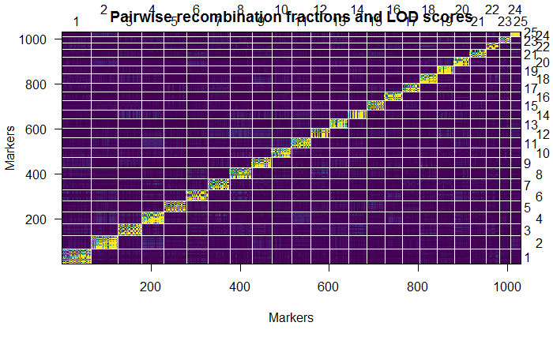

Drop marker in LG25:

```r
pull.map(FamA_F.LP, chr="25")
```

```
dDocent_Contig_22126
                   0
```

## Establish initial marker order

Establish initial marker order within LGs using greedy algorithm. Adds one marker at a time with previously added marker locations fixed. Position determined by minimizing number of obligate cross overs.

```r
# Create final cross/map object
FamA_F.final <- FamA_F.LP

# establish initial marker orders
FamA_F.final <- orderMarkers(FamA_F.final, chr=1:24)
```

## Initial quality assessment

### Examine pairwise linkage & Identify gaps between markers

Plot rf vs LOD after ordering markers:

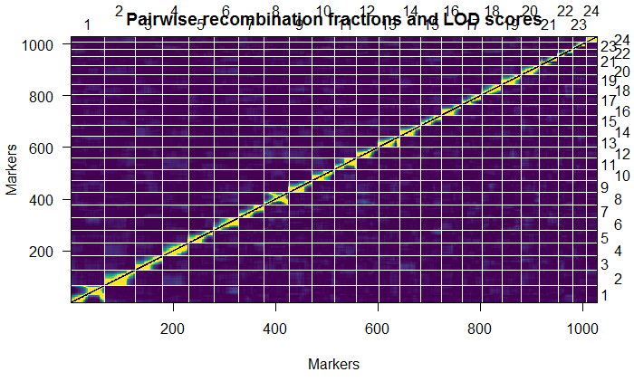

Large gaps between markers indicate that adjacent markers are only weakly linked. Compare average and largest spacing per LG.

```r
summaryMap(FamA_F.final)
```

```
        n.mar length ave.spacing max.spacing
1          66   98.3         1.5        14.9
2          60   56.5         1.0         5.9
3          53   59.8         1.1         6.5
4          50   49.3         1.0         5.2
5          50   64.6         1.3         7.2
6          49   57.6         1.2         6.5
7          49   66.6         1.4        11.6
8          49  116.0         2.4        14.1
9          45   54.8         1.2         9.4
10         44   86.0         2.0        18.3
11         43   76.7         1.8         8.7
12         43   62.6         1.5         7.3
13         42   88.4         2.2        24.9
14         41   49.9         1.2         6.5
15         40   57.5         1.5         8.7
16         40   52.4         1.3        10.1
17         39  102.4         2.7        34.9
18         39   55.6         1.5         4.5
19         38   61.7         1.7        10.9
20         36   46.3         1.3         5.2
21         36  116.7         3.3        15.7
22         29   58.0         2.1        16.6
23         26   58.4         2.3        16.6
24         22   52.3         2.5        22.0
overall  1029 1648.6         1.6        34.9
```

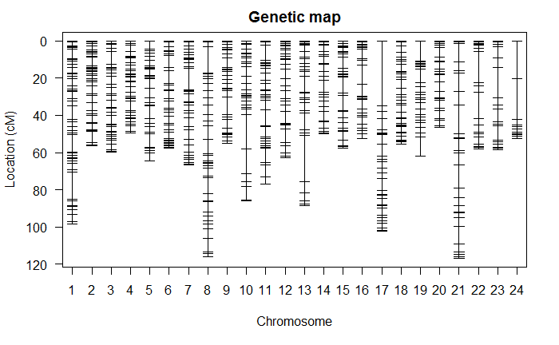

Drop markers one by one to determine change in chromosome length & change in log likelihood. Identify markers that result in smaller estimated chromosome length and increased LOD. Dropping terminal markers will usually result in decreased length.

```r
# drop each marker and compare effect
dropone <- droponemarker(FamA_F.final, maxit = 4000, tol = 1e-6,
                         error.prob = 0.001, verbose = TRUE) %>%
  add_rownames("Marker") %>%
  gather("Effect", "Change", 4:5)

# plot results
plot_dropone <- function(dropone){
  p <- ggplot(dropone, aes(x = pos, y = Change)) +
    geom_line() +
    geom_point(shape = 21, size = 2,
               color = "black", fill = "white") +
    facet_grid(Effect ~ ., scales = "free") +
    labs(x = paste("LG", dropone$chr, "Position", sep =" "), y = "Change if marker dropped") +
    theme_facet
  print(p)
}

dropone %>%
  group_by(chr) %>%
  do(plot = plot_dropone(.)) %>%
  ungroup()
```

Compare effect in terms of change in length and likelihood and identify top 10 loci with strongest effect per LG.

```r
# data frame with top10 markers with strongest effect
dropone_sum <- dropone %>%
  spread("Effect", "Change") %>%
  group_by(chr) %>%
  top_n(10, LOD) %>%
  ungroup() %>%
  arrange(chr, LOD)
```

Drop markers as necessary and re-estimate map.

```r
summaryMap(FamA_F.final)
```

```
        n.mar length ave.spacing max.spacing
1          66   96.0         1.5        14.9
2          60   53.6         0.9         5.9
3          53   53.8         1.0         6.6
4          50   44.9         0.9         5.2
5          50   62.4         1.3         7.2
6          49   55.3         1.2         6.6
7          49   59.8         1.2        10.9
8          48  102.8         2.2        14.1
9          45   52.4         1.2         9.4
10         43   59.9         1.4         7.3
11         43   74.8         1.8         8.7
12         43   60.9         1.5         7.3
13         42   86.1         2.1        25.0
14         40   48.7         1.2         6.6
15         40   56.9         1.5         8.7
16         40   51.1         1.3         9.9
17         38   65.8         1.8         6.6
18         39   51.6         1.4         4.5
19         38   60.1         1.6        10.2
20         36   46.1         1.3         5.2
21         35   95.4         2.8        14.8
22         29   56.5         2.0        16.3
23         26   58.3         2.3        16.6
24         20    9.4         0.5         3.2
overall  1022 1462.5         1.5        25.0
```

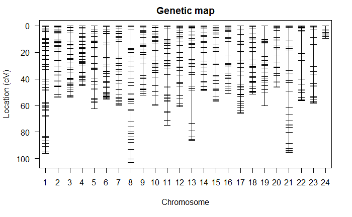

```r
par(ps=12, cex.lab=1)
plotMap(FamA_F.final, horizontal=FALSE, shift=TRUE, show.marker.names=FALSE, alternate.chrid=FALSE)
```

### Identify individuals with high number of XO

Observed number of crossovers per individual:

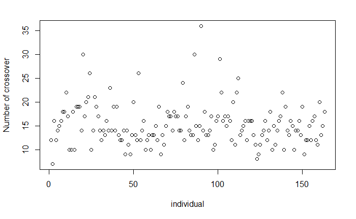

### Estimate genotyping error rate

Estimate genotyping error rate.

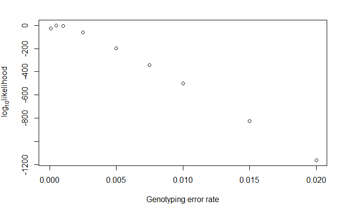

Genotyping error rate with highest likelihood is 0.0005.

### Identify genotyping errors and code as missing

Tight double-crossovers (single marker out of phase with adjacent markers) indicate genotyping errors. Identify double cross-overs by calculating genotyping error LOD scores (Lincoln & Lander 1992). Calculate errorload (genotype being in error vs not being in error). Plot grid of LOD scores indicating genotypes likely to be in error: darker pixels likely to be error: white (LOD <2), grey (2 < LOD < 3), pink (3 < LOD < 4.5), purple (LOD >4.5)

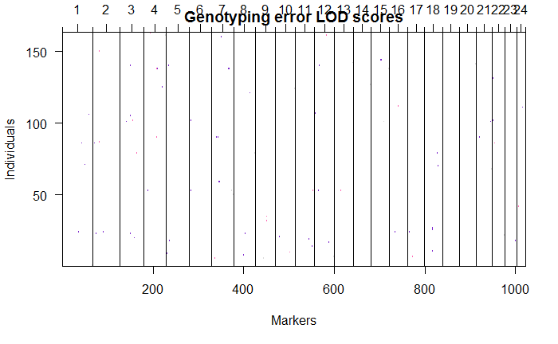

Eliminate genotypes (coded as missing) for LOD > 6 and re-estimate map.

| chr | id | marker | errorlod |
| --- | --- | --- | --- |
| 9 | 18 | dDocent_Contig_39211 | 18.000000 |
| 10 | 149 | dDocent_Contig_315075 | 18.000000 |
| 9 | 6 | dDocent_Contig_39211 | 18.000000 |
| 8 | 22 | dDocent_Contig_54431 | 18.000000 |
| 14 | 36 | dDocent_Contig_28647 | 18.000000 |
| 9 | 47 | dDocent_Contig_39211 | 18.000000 |
| 8 | 85 | dDocent_Contig_54431 | 18.000000 |
| 9 | 139 | dDocent_Contig_2654 | 18.000000 |
| 11 | 111 | dDocent_Contig_42202 | 18.000000 |
| 12 | 89 | dDocent_Contig_248473 | 17.999998 |

[output cut: 100 more lines]

## Re-order markers by LG and compare alternate orders

### Compare number obligate XO, LOD & Chromosome length to determine best order

Re-order markers after loci and individuals have been removed and use sliding window to compare alternate orders in terms of number of obligate cross overs and likelihood.

```r
# compare number of obligate crossovers for alternate orders
FamA_F.XO <- lapply(c(1:24), function(chr) {
  rip <- ripple(FamA_F.final, chr = chr, window = 7, method="countxo", error.prob = 0.001, maxit = 2000, tol = 1e-6)
  rip <- rip[1:11,]
})

# access each element in list using [[]]
# Ch1_XO <- as.data.frame(FamA_F.XO[[1]]) %>%
#  rename(Chr1 = obligXO) %>%
#  select(Chr1)

FamA_F.lik <- lapply(c(1:24), function(chr) {
  rip.lik <- ripple(FamA_F.final, chr = chr, window = 5, method="likelihood", error.prob=0.002, maxit=2000, tol=1e-4)
  rip.lik <- rip.lik[1:11,]
})
```

### Switch marker order as necessary

Identify order with lowest number of XO and highest LOD while minimizing chromosome length.

## Post-odering quality assessment II

### Examine pairwise linkage & Identify gaps between markers

Plot rf vs LOD

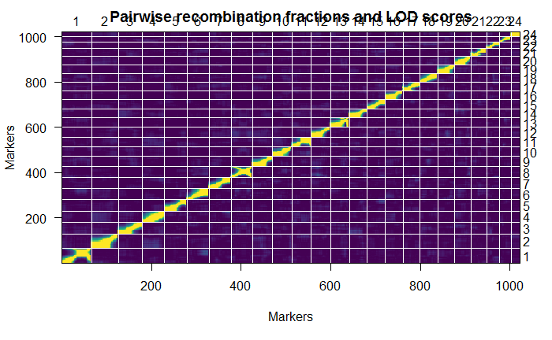

Identify large gaps between markers which is indicative of adjacent markers being only weakly linked.

```r
summaryMap(FamA_F.final)
```

```
        n.mar length ave.spacing max.spacing
1          66   96.0         1.5        14.9
2          60   53.6         0.9         5.9
3          53   53.8         1.0         6.6
4          50   44.9         0.9         5.2
5          50   62.4         1.3         7.2
6          49   55.3         1.2         6.6
7          49   59.8         1.2        10.9
8          48  102.8         2.2        14.1
9          45   52.4         1.2         9.4
10         43   59.9         1.4         7.3
11         43   74.8         1.8         8.7
12         43   60.9         1.5         7.3
13         42   86.1         2.1        25.0
14         40   48.7         1.2         6.6
15         40   56.9         1.5         8.7
16         40   51.1         1.3         9.9
17         38   65.8         1.8         6.6
18         39   51.6         1.4         4.5
19         38   60.1         1.6        10.2
20         36   46.1         1.3         5.2
21         35   95.4         2.8        14.8
22         29   56.5         2.0        16.3
23         26   58.3         2.3        16.6
24         20    9.4         0.5         3.2
overall  1022 1462.5         1.5        25.0
```

Plot maps of all linkage groups:

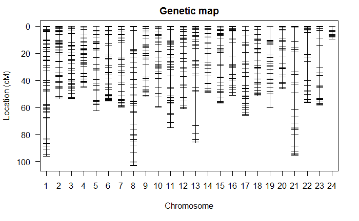

Drop markers one by one determine change in chromosome length & change in log likelihood. Identify markers that result in smaller estimated chromosome length and increased LOD.

```r
# drop each marker and compare effect
dropone <- droponemarker(FamA_F.final, maxit = 4000, tol = 1e-6,
                         error.prob = 0.001, verbose = TRUE) %>%
  add_rownames("Marker") %>%
  gather("Effect", "Change", 4:5)

# plot results
plot_dropone <- function(dropone){
  p <- ggplot(dropone, aes(x = pos, y = Change)) +
    geom_line() +
    geom_point(shape = 21, size = 2,
               color = "black", fill = "white") +
    facet_grid(Effect ~ ., scales = "free") +
    labs(x = paste("LG", dropone$chr, "Position", sep =" "), y = "Change if marker dropped") +
    theme_facet
  print(p)
}

dropone %>%
  group_by(chr) %>%
  do(plot = plot_dropone(.)) %>%
  ungroup()
```

Compare effect in terms of change in length and likelihood and identify top 10 loci with strongest effect per LG.

```r
# data frame with top10 markers with strongest effect
dropone_sum <- dropone %>%
  spread("Effect", "Change") %>%
  group_by(chr) %>%
  top_n(10, LOD) %>%
  ungroup() %>%
  arrange(chr, LOD)
```

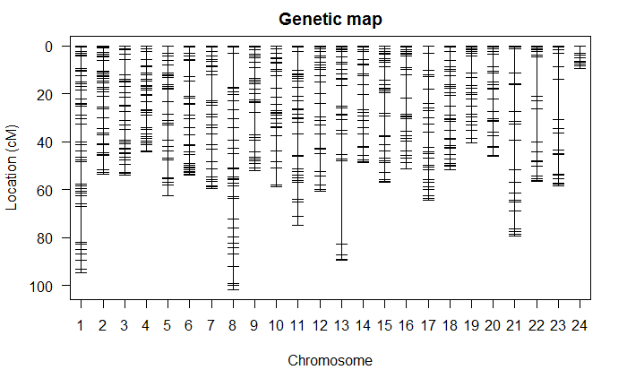

### Identify individuals with high number of XO

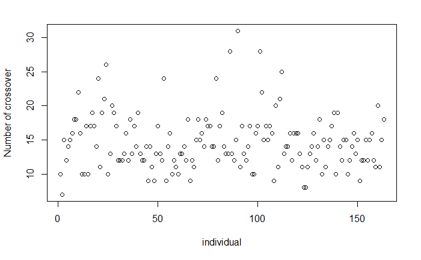

## Finalize map

```r
# print summary map and map data
SummaryFamA_F <- summaryMap(FamA_F.final)
write.table(SummaryFamA_F, file = "data/LINKMAP/SummaryFamA_F.map",
          quote = FALSE, sep = "\t", row.names = FALSE)
FamA_F.map <- pull.map(FamA_F.final,as.table = TRUE)
write.table(FamA_F.map, file = "data/LINKMAP/FamA_F.map",
            quote = FALSE, sep = "\t", row.names = FALSE)
```

# Family A Male Map

## Load data

Required inputfiles are `genfile`: `*.raw` generated using `convert.pl` to convert filtered `*.tsv`-output from haplotyper and `mapfile`: `*.map` text file with two columns (first column is putative linkage group, second column is markername). Need to create mapfile based on markers in genfile before analysis.

```r
# load data
FamA_M <- read.cross("mm", dir="data/LINKMAP/",
                     "FamA-M.raw", "FamA-M.map", estimate.map = FALSE)
```

```
 --Read the following data:
    Type of cross:          bc
    Number of individuals:  174
    Number of markers:      1856
    Number of phenotypes:   1
 --Cross type: bc
```

```r
# number of individuals/loci in data set
Sum_FamA_M.raw <- summary(FamA_M)
```

Raw data set contains 174 individuals and 1856 loci.

## Pre-mapping quality control

### Filter 1: Missing data

Missing genotypes (loci/individuals)

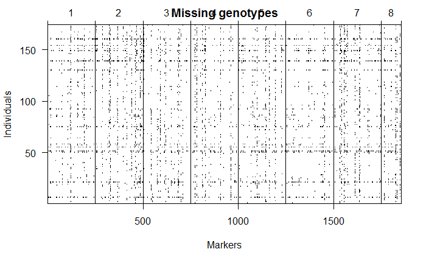

Omit loci with > 5% missing data and individuals with > 25% missing data.

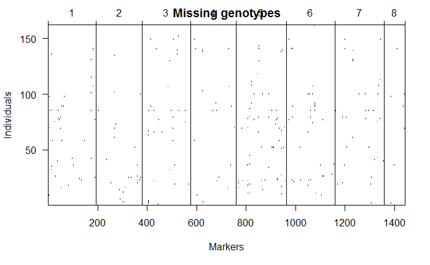

After filtering data set contains 163 individuals and 1453 loci.

### Filter 2: Omit duplicate individuals

Compare genotypes of pairs of individuals to identify pairs with unusually similar genotypes

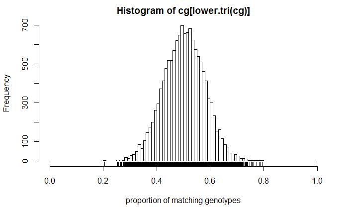

No matching individuals were identified.

Data set contains 163 individuals and 1453 loci.

### Filter 3: Omit duplicate markers

Identify matching markers. Drop duplicate markers but create table of corresponding marker to be mapped so the can be added post-mapping.

After filtering 987 loci are retained.

### Filter 4: Drop loci with distroted segregation patterns

Loci should have specific segregation patterns based on marker type.

### Filter 5: Genotype frequencies by individual

Determine genotype frequencies by individual and remove individuals as necessary.

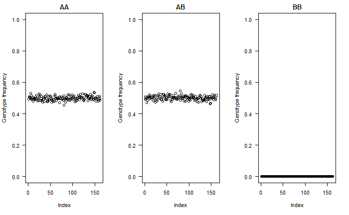

After filtering 162 individuals are retained.

## Determine correct linkage phase

Estimate recombination fraction (rf) & LOD score for each marker pair. Potentially switched markers are pairs of marker with strong association (LOD score) but rf >> 1/4.

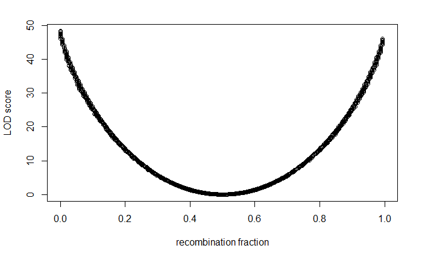

Form initial linkage groups and re-organize loci into initial LGs.

```r
init.lg <- formLinkageGroups(FamA_M.LP, max.rf = 0.35, min.lod = 6)
table(init.lg[,2])
```

```
 1  2  3  4  5  6  7  8  9 10 11 12 13 14 15 16 17 18 19 20 21 22 23 24 25 26 27 28 29 30 31
33 32 29 29 26 25 25 25 25 25 24 24 24 23 23 23 22 22 21 21 21 20 20 20 19 19 18 18 18 18 18
32 33 34 35 36 37 38 39 40 41 42 43 44 45 46 47 48 49 50
18 17 17 17 17 17 17 17 17 16 16 15 15 15 15 14 14  1  1
```

```r
# re-organize markers into inferred initial LGs
FamA_M.LP <- formLinkageGroups(FamA_M.LP, max.rf = 0.35, min.lod = 6, reorgMarkers=TRUE)
```

Plot rf vs LOD to identify chromosomes to switch alleles for.

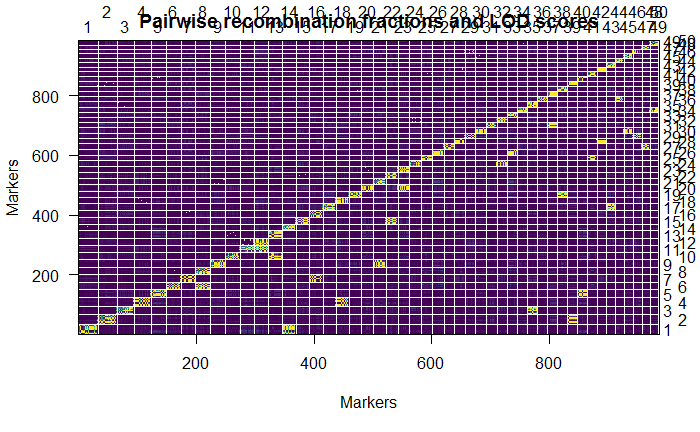

Switch alleles, re-estimate rf, form new linkage groups and re-organize markers.

```r
# use plot to identify chromosomes to switch alleles for
for (chr in c(8, 12:14, 16, 18,
              21:23, 32:33, 35, 37:48)){
  toswitch <- markernames(FamA_M.LP, chr=(chr))
  FamA_M.LP <- switchAlleles(FamA_M.LP, toswitch)
}

# re-estimate rf
FamA_M.LP <- est.rf(FamA_M.LP)

# form new linkage groups & re-organize markers
init.lg <- formLinkageGroups(FamA_M.LP, max.rf=0.35, min.lod=6)
table(init.lg[,2])
FamA_M.LP <- formLinkageGroups(FamA_M.LP, max.rf=0.35, min.lod=6, reorgMarkers=TRUE)
```

Plot rf vs LOD after switching alleles:

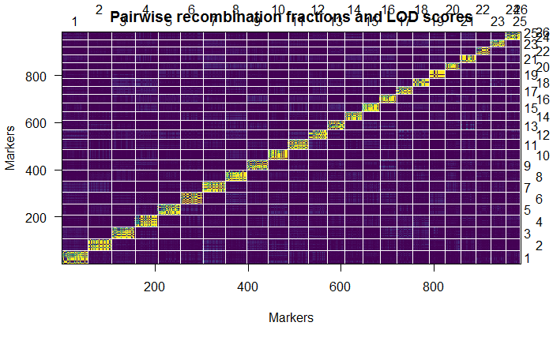

Drop marker in LG25 and 26:

```r
pull.map(FamA_M.LP, chr="26")
```

```
dDocent_Contig_25489
                   0
```

## Establish initial marker order

Establish initial marker order within LGs using greedy algorithm. Adds one marker at a time with previously added marker locations fixed. Position determined by minimizing number of obligate cross overs.

## Initial quality assessment

### Examine pairwise linkage & Identify gaps between markers

Plot rf vs LOD after ordering markers:

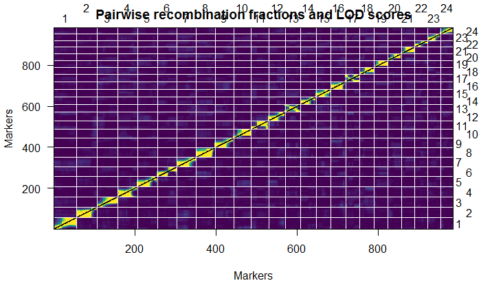

Large gaps between markers indicate that adjacent markers are only weakly linked. Compare average and largest spacing per LG.

```r
summaryMap(FamA_M.final)
```

```
        n.mar length ave.spacing max.spacing
1          56   62.9         1.1         6.6
2          51   66.6         1.3        11.8
3          50   67.5         1.4         7.3
4          49   81.0         1.7         8.7
5          49   79.3         1.7        10.2
6          48   90.5         1.9        14.9
7          48   62.7         1.3         8.0
8          46   60.6         1.3         8.0
9          46   63.9         1.4         5.9
10         43   60.6         1.4        12.6
11         43   89.1         2.1        42.0
12         41   48.7         1.2         7.3
13         38  111.7         3.0        19.4
14         38   66.3         1.8        15.8
15         37   61.0         1.7         9.1
16         36   56.0         1.6        11.8
17         35  103.7         3.1        12.6
18         35   46.8         1.4         9.9
19         34   62.9         1.9        17.6
20         33   57.7         1.8        13.4
21         33   58.8         1.8        17.6
22         32   63.1         2.0        10.2
23         32   56.3         1.8         7.3
24         31   96.9         3.2        43.4
overall   984 1674.6         1.7        43.4
```

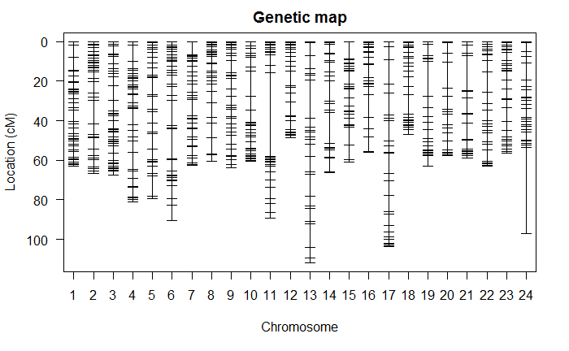

Drop markers one by one to determine change in chromosome length & change in log likelihood. Identify markers that result in smaller estimated chromosome length and increased LOD. Dropping terminal markers will usually result in decreased length.

```r
# drop each marker and compare effect
dropone <- droponemarker(FamA_M.final, maxit = 4000, tol = 1e-6,
                         error.prob = 0.001, verbose = TRUE) %>%
  add_rownames("Marker") %>%
  gather("Effect", "Change", 4:5)
```

[output not shown]

```
Deprecated, use tibble::rownames_to_column() instead.
```

Compare effect in terms of change in length and likelihood and identify top 10 loci with strongest effect per LG.

```r
# data frame with top10 markers with strongest effect
dropone_sum <- dropone %>%
  spread("Effect", "Change") %>%
  group_by(chr) %>%
  top_n(10, LOD) %>%
  ungroup() %>%
  arrange(chr, LOD)
```

Drop markers as necessary and re-estimate map.

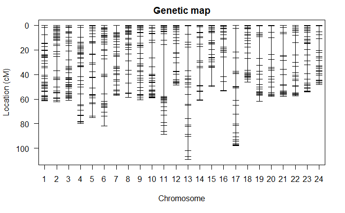

### Identify individuals with high number of XO

Observed number of crossovers per individual; eliminate individuals with excessively high number of crossovers >50).

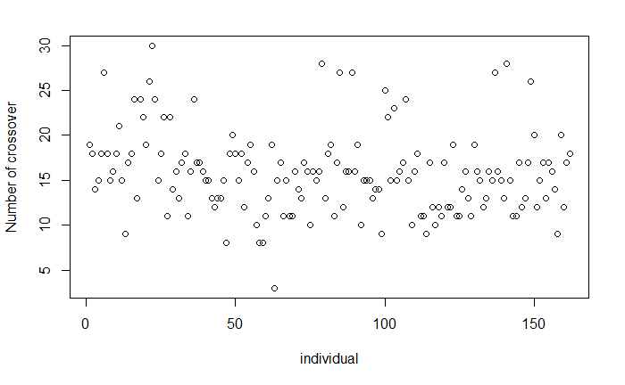

### Estimate genotyping error rate

Estimate genotyping error rate.

```r
# Estimate genotyping error rate
loglik <- err <- c(0.0001, 0.0005, 0.001, 0.0025, 0.005, 0.0075, 0.01, 0.015, 0.02)
for(i in seq(along=err)) {
  cat(i, "of", length(err), "\n")
  tempmap <- est.map(FamA_M.final, error.prob=err[i])
  loglik[i] <- sum(sapply(tempmap, attr, "loglik"))
}
```

```
1 of 9
2 of 9
3 of 9
4 of 9
5 of 9
6 of 9
7 of 9
8 of 9
9 of 9
```

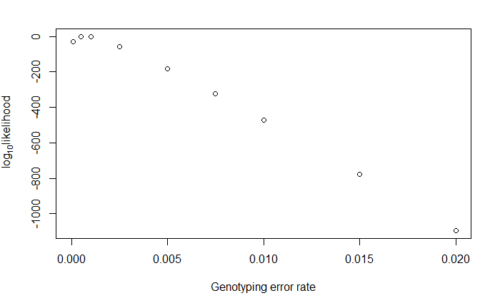

```r
lod <- (loglik - max(loglik))/log(10)
# plot log10 likelihood
par(mfrow=c(1,1), ps=12, cex=1)
plot(err, lod, xlab="Genotyping error rate", xlim=c(0,0.02), ylab=expression(paste(log[10], "likelihood")))
```

Genotyping error rate with highest likelihood is 0.0005.

### Identify genotyping errors and code as missing

Tight double-crossovers (single marker out of phase with adjacent markers) indicate genotyping errors. Identify double cross-overs by calculating genotyping error LOD scores (Lincoln & Lander 1992). Calculate errorload (genotype being in error vs not being in error). Plot grid of LOD scores indicating genotypes likely to be in error: darker pixels likely to be error: white (LOD <2), grey (2 < LOD < 3), pink (3 < LOD < 4.5), purple (LOD >4.5)

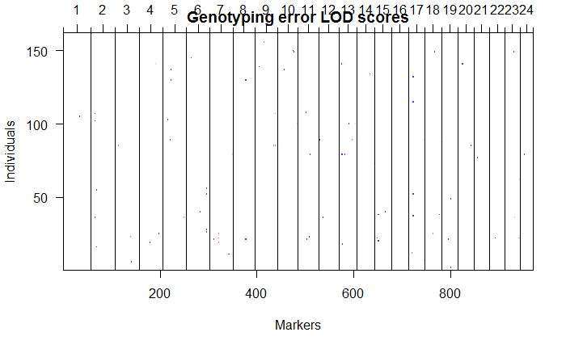

Eliminate genotypes (coded as missing) for LOD > 6 and re-estimate map.

## Re-order markers by LG and compare alternate orders

### Compare number obligate XO, LOD & Chromosome length to determine best order

Re-order markers after loci and individuals have been removed and use sliding window to compare alternate orders in terms of number of obligate cross overs and likelihood.

```r
# compare number of obligate crossovers for alternate orders
FamA_M.XO <- lapply(c(1:24), function(chr) {
  rip <- ripple(FamA_M.final, chr = chr, window = 7, method="countxo", error.prob = 0.001, maxit = 2000, tol = 1e-6)
  rip <- rip[1:11,]
})

# access each element in list using [[]]
# Ch1_XO <- as.data.frame(FamA_M.XO[[1]]) %>%
#  rename(Chr1 = obligXO) %>%
#  select(Chr1)

FamA_M.lik <- lapply(c(1:24), function(chr) {
  rip.lik <- ripple(FamA_M.final, chr = chr, window = 5, method="likelihood", error.prob=0.002, maxit=2000, tol=1e-4)
  rip.lik <- rip.lik[1:11,]
})
```

### Switch marker order as necessary

Identify order with lowest number of XO and highest LOD while minimizing chromosome length.